# R Notebook

Création d’un modèle de classification randomForest

Importation des données et de la libraire randomForest. On enlève les variables inutiles et redondantes ( pas besoin d’avoir start time et stop time quand on a runtime)

```r
library(randomForest)
data = read.csv('C:\\Users\\ibiza\\OneDrive\\Desktop\\Data\\1.csv')
data_2 = data[-c(5,6,12,13,15,16,17,18,19,20,21,22,23)]
```

On crée un histogramme de la variable ‘total_energy_consumption’ afin d’avoir une idée générale de la distribution de la variable.

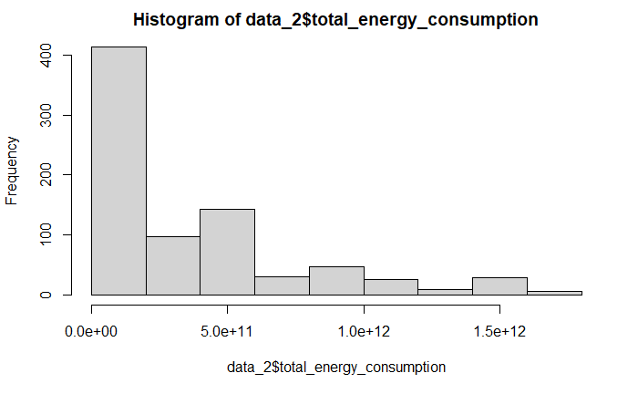

```r
hist(data_2$total_energy_consumption)
```

Transformation de la variable ‘total_energy_consumption’ en variable catégorielle afin de pouvoir appliquer un arbre de classification. Ces classes ont vocation à etre remplacée par les “vraies” classes trouvées par les algorithmes de classification de séries temporelles.

```r
decoupage = function(x) {
  if (x <= 2.86576685e+09/2)
    return ("Catégorie 0")
  else if (x <= 1.82064049e+11)
    return ("Catégorie 1")
  else if (x <= 3.61262332e+11)
    return ("Catégorie 2")
  else if (x <= 5.40460614e+11)
    return ("Catégorie 3")
  else if (x <= 7.19658896e+11)
    return ("Catégorie 4")
  else if (x <= 8.98857179e+11)
    return ("Catégorie 5")
  else if (x <= 1.07805546e+12)
    return ("Catégorie 6")
  else if (x <= 1.25725374e+12)
    return ("Catégorie 8")
  else if (x <= 1.43645203e+12)
    return ("Catégorie 9")
  else if (x <= 1.61565031e+12)
    return ("Catégorie 10")
  else
    return ("Catégorie 11")
}
data_2$catégorie = apply(data_2[,c("total_energy_consumption"),drop = F],1,decoupage)
```

On enlève la variable ‘total_energy_consumption’et on précise que la nouvelle variable ’catégorie’ (qui représente la consommation énergétique) est un facteur. Cette étape est nécessaire pour que le randomForest fonctionne

```r
data_3 = data_2[-c(11)]
data_3$catégorie = factor(data_3$catégorie)
```

On sépare en train/test à hauteur de 70%/30%

```r
train = sample(nrow(data_3), 0.7*nrow(data_3), replace = FALSE)
TrainSet = data_3[train,]
ValidSet = data_3[-train,]
```

```r
foret_1 = randomForest(catégorie ~ ., data = TrainSet, importance = TRUE,proximity = TRUE)
foret_1
```

```
Call:
 randomForest(formula = catégorie ~ ., data = TrainSet, importance = TRUE,      proximity = TRUE)
               Type of random forest: classification
                     Number of trees: 500
No. of variables tried at each split: 3

        OOB estimate of  error rate: 6.64%
Confusion matrix:
             Catégorie 1 Catégorie 10 Catégorie 11 Catégorie 2 Catégorie 3 Catégorie 4 Catégorie 5 Catégorie 6 Catégorie 8 Catégorie 9
Catégorie 1          285            0            0           2           0           0           0           2           0           0
Catégorie 10           0           13            1           0           0           0           0           0           0           0
Catégorie 11           0            2            0           0           0           0           0           0           1           0
Catégorie 2            2            0            0          45           1           0           0           0           0           0
Catégorie 3            0            0            0           0          89           1           0           0           0           0
Catégorie 4            1            0            0           1           3          35           3           0           0           0
Catégorie 5            0            0            0           0           0           3          36           1           0           0
Catégorie 6            5            0            0           0           0           0           0           0           2           0
Catégorie 8            0            1            0           0           0           0           0           1          15           1
Catégorie 9            0            1            0           0           0           0           0           0           2           2
             class.error
Catégorie 1   0.01384083
Catégorie 10  0.07142857
Catégorie 11  1.00000000
Catégorie 2   0.06250000
Catégorie 3   0.01111111
Catégorie 4   0.18604651
Catégorie 5   0.10000000
Catégorie 6   1.00000000
Catégorie 8   0.16666667
Catégorie 9   0.60000000
```

```r
predTrain <- predict(foret_1, TrainSet, type = "class")
table(predTrain, TrainSet$catégorie)
```

```
predTrain      Catégorie 1 Catégorie 10 Catégorie 11 Catégorie 2 Catégorie 3 Catégorie 4 Catégorie 5 Catégorie 6 Catégorie 8 Catégorie 9
  Catégorie 1          289            0            0           0           0           0           0           0           0           0
  Catégorie 10           0           14            0           0           0           0           0           0           0           0
  Catégorie 11           0            0            3           0           0           0           0           0           0           0
  Catégorie 2            0            0            0          47           0           0           0           0           0           0
  Catégorie 3            0            0            0           1          90           1           0           0           0           0
  Catégorie 4            0            0            0           0           0          42           0           0           0           0
  Catégorie 5            0            0            0           0           0           0          40           0           0           0
  Catégorie 6            0            0            0           0           0           0           0           6           0           0
  Catégorie 8            0            0            0           0           0           0           0           1          18           0
  Catégorie 9            0            0            0           0           0           0           0           0           0           5
```

```r
predValid <- predict(foret_1, ValidSet, type = "class")
mean(predValid == ValidSet$catégorie)
```

```
[1] 0.9083333
```

```r
table(predValid,ValidSet$catégorie)
```

```
predValid      Catégorie 1 Catégorie 10 Catégorie 11 Catégorie 2 Catégorie 3 Catégorie 4 Catégorie 5 Catégorie 6 Catégorie 8 Catégorie 9
  Catégorie 1          108            0            0           1           0           0           0           0           0           0
  Catégorie 10           0           12            1           0           0           0           0           0           0           1
  Catégorie 11           0            0            2           0           0           0           0           0           0           0
  Catégorie 2            0            0            0          19           0           0           0           0           0           0
  Catégorie 3            1            0            0           1          39           4           0           0           0           0
  Catégorie 4            0            0            0           0           5          11           0           0           0           0
  Catégorie 5            6            0            0           0           0           0          19           1           0           0
  Catégorie 6            0            0            0           0           0           0           0           1           0           0
  Catégorie 8            0            0            0           0           0           0           0           1           4           0
  Catégorie 9            0            0            0           0           0           0           0           0           0           3
```

On regarde quelles variables sont les plus importantes. MeanDecreaseAccuracy indique à quel point la précision diminue quand la variable n’est pas prise en compte pour une séparation au niveau d’un noeud. MeanDecreaseGini indique à quel point prendre en compte cette variable pour la séparation d’un noeud résulte en une diminution de l’impureté de ce noeud. Ainsi, les variables les plus predictives sont : - run_time_oar - job_user_oar - submission_time_oar (étonnant) - job_id_oar _host_oar (la machine semble avoir un rôle à jouer, ou alors est-ce l’inverse, c’est à dire que certaines machines sont choisies en priorité pour effecteur les jobs les plus gourmants par exemple ?)

```r
importance(foret_1)
```

```
                    Catégorie 1 Catégorie 10 Catégorie 11 Catégorie 2 Catégorie 3 Catégorie 4 Catégorie 5 Catégorie 6 Catégorie 8
job_id                17.290127    10.088204     3.254400  17.6900261   21.532920   24.698655   18.561824    1.834109    9.597099
host_oar              13.806758     7.645092    -2.679567   6.5527752    5.996233    5.002750   10.396907    6.929065    6.142175
cigri_oar              0.000000     0.000000     0.000000   0.0000000    0.000000    0.000000    0.000000    0.000000    0.000000
submission_time_oar   18.060204     8.610516     2.008048  16.0473012   22.154401   23.809917   19.385617    3.454631   11.674359
processor             -3.274428    -3.195344    -3.755137  -0.7286287   -4.465380   -5.202672   -5.859663   -6.302474   -6.660993
job_type_oar          -1.416283     1.397694     0.000000   2.8214874    2.562518    1.001002    1.001002    0.000000    1.001002
job_user_oar          19.816184    23.316065     5.729560  22.3413951   28.926634   32.452014   22.724767    6.143291   26.006017
resource_ids_oar      -2.941868    -2.132169    -3.116819  -2.3217912   -5.124808   -4.670665   -7.700283   -5.426628   -7.072827
nb_resources           0.000000     0.000000     0.000000   0.0000000    0.000000    0.000000    0.000000    0.000000    0.000000
runtime_oar           64.371199    28.906468     6.758613  50.9200713   57.279008   47.960042   44.451131    9.815686   31.040569
                    Catégorie 9 MeanDecreaseAccuracy MeanDecreaseGini
job_id                10.080951            30.023864       39.0983397
host_oar               6.090059            20.581560       22.4864399
cigri_oar              0.000000             0.000000        0.0000000
submission_time_oar    9.552315            29.069054       39.8420404
processor              2.833404           -10.434700        2.6298890
job_type_oar           0.000000             3.410332        0.2056591
job_user_oar          10.275169            39.561351       50.6859339
resource_ids_oar       1.749811           -11.315870        2.4292984
nb_resources           0.000000             0.000000        0.0000000
runtime_oar           13.285970            77.063029      180.7450341
```

On essaye de trouver le nombre optimal de variables à prendre en compte pour les séparations

```r
Précisions=c()
i=5
for (i in 3:10) {
  foret_3 <- randomForest(catégorie ~ ., data = TrainSet, ntree = 500, mtry = i, importance = TRUE)
  predValid <- predict(foret_3, ValidSet, type = "class")
  Précisions[i-2] = mean(predValid == ValidSet$catégorie)
}
Précisions
```

```
[1] 0.9083333 0.9291667 0.9333333 0.9333333 0.9250000 0.9291667 0.9375000 0.9625000
```

Ce modèle a des limites évidentes : La prédiction repose presque uniquement sur le runtime. Peut être serait-il intéressent d’avoir accès à plus de variables explicatives, où à défaut à plus de données pour affiner la prédiction.

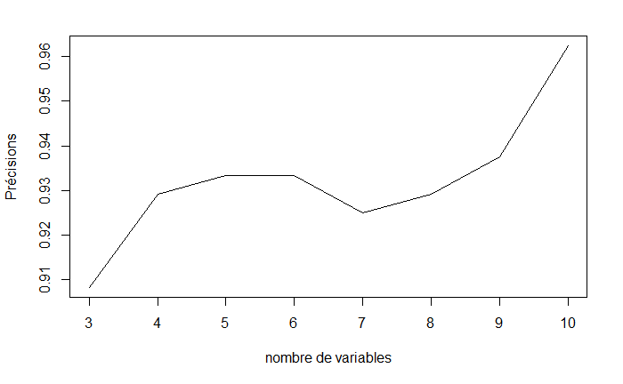

```r
plot(3:10,Précisions,type='l',xlab ='nombre de variables')
```